# Analysis of the Lactobacillus literature

Sander Wuyts

November 21, 2018

# Introduction

This pipeline describes how I analyzed the Lactobacillus literature

# Getting the data

I went to the Scopus website and looked for articles with the following criteria, where “lactobacillus” was in either the title or the abstract:

- PART 1: TITLE-ABS-KEY(Lactobacillus) AND ( LIMIT-TO ( DOCTYPE,“ar” ) ) AND ( LIMIT-TO ( LANGUAGE,“English” ) ) AND ( LIMIT-TO ( SRCTYPE,“j” ) )
- PART2: TITLE-ABS-KEY(Lactobacillus) AND ( LIMIT-TO ( DOCTYPE,“ar” ) ) AND ( LIMIT-TO ( LANGUAGE,“English” ) ) AND ( LIMIT-TO ( SRCTYPE,“j” ) ) AND PUBYEAR < 2010
- PART3: TITLE-ABS-KEY(Lactobacillus) AND ( LIMIT-TO ( DOCTYPE,“ar” ) ) AND ( LIMIT-TO ( LANGUAGE,“English” ) ) AND ( LIMIT-TO ( SRCTYPE,“j” ) ) AND PUBYEAR < 1978

I manually saved all queries as a csv file. This was done on 3 May 2018. In the future, this part can probably be automated if you find a better scrapable data source.

# Read in data

Let’s load all our packages

```r
library(tidyverse)
library(tidytext)
library(ggpubr)
library(lubridate)
```

Now, read in the data.

```r
scopus <- read_csv("scopus_part1.csv") %>%
  rbind(read_csv("scopus_part2.csv")) %>%
  rbind(read_csv("scopus_part3.csv")) %>%
  distinct()
scopus_author_count <- read_tsv("scopus_author_count.tsv") %>%
  select(-X3)
scopus_country_count <- read_tsv("scopus_country_count.tsv")
scopus_research_area_count <- read_tsv("scopus_research_area_count.tsv")
```

# Analysis

Total amount of articles per year:

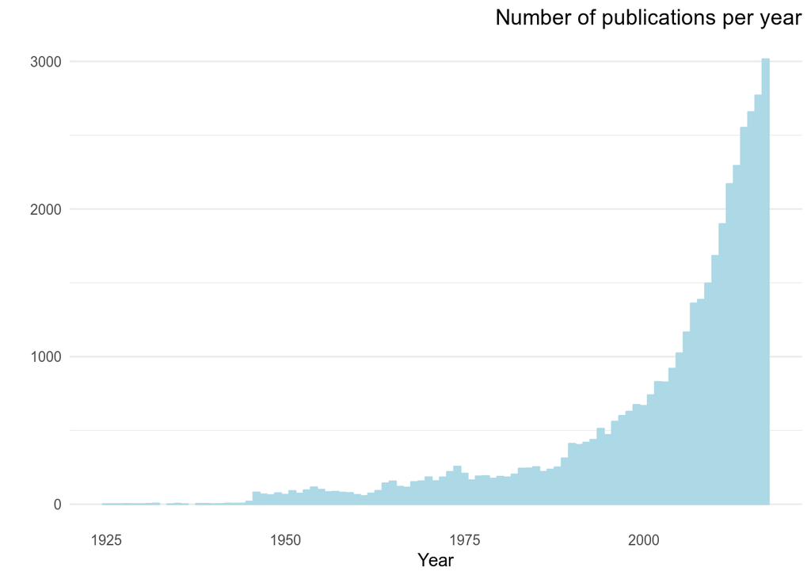

```r
A1 <- scopus %>%
  group_by(Year) %>%
  summarise(count = n()) %>%
  filter(Year != 2018) %>%
  ggplot(aes(x = Year, y = count)) +
  geom_col(colour = "lightblue", fill = "lightblue") +
  theme_minimal() +
  theme(panel.grid.major.x = element_blank(),
        panel.grid.minor.x = element_blank(),
        plot.title = element_text(hjust = 1)) +
  ylab("") +
  ggtitle("Number of publications per year")

A1
```

Cumulative sum

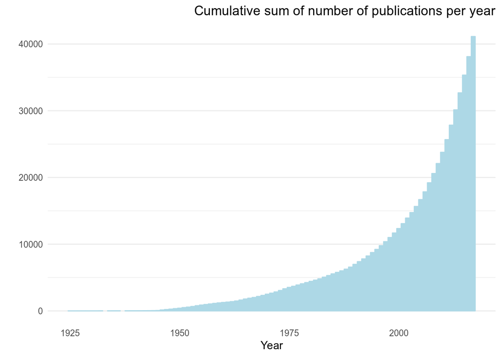

```r
scopus %>%
  group_by(Year) %>%
  summarise(count = n()) %>%
  filter(Year != 2018) %>%
  ungroup() %>%
  mutate(cumsum = cumsum(count)) %>%
  ggplot(aes(x = Year, y = cumsum)) +
  geom_col(colour = "lightblue", fill = "lightblue") +
  theme_minimal() +
  theme(panel.grid.major.x = element_blank(),
        panel.grid.minor.x = element_blank(),
        plot.title = element_text(hjust = 1)) +

  ylab("") +
  ggtitle("Cumulative sum of number of publications per year")
```

What research areas?

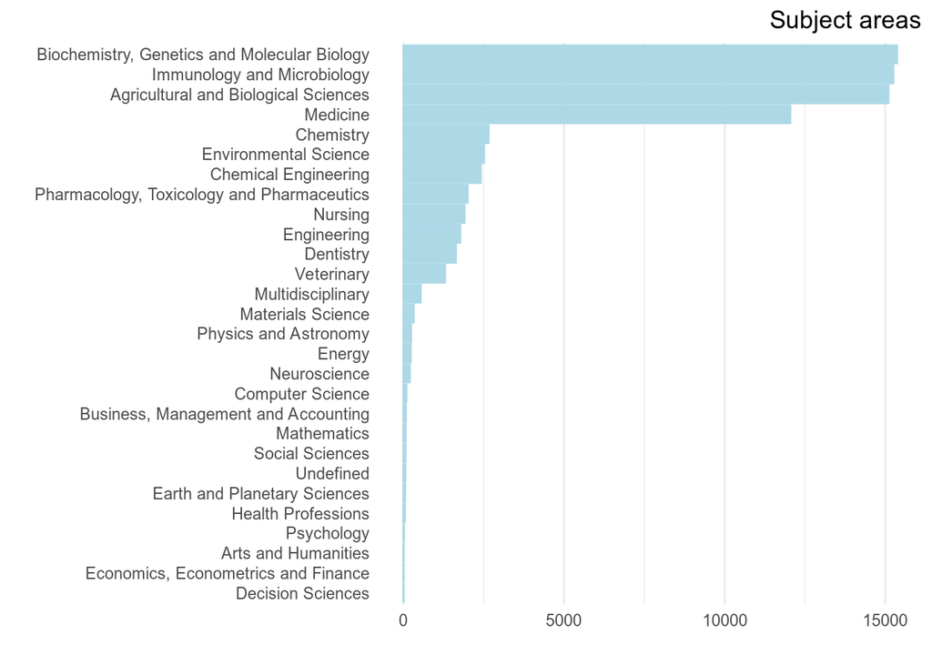

```r
D1 <- scopus_research_area_count %>%
  ggplot(aes(x = reorder(`SUBJECT AREA`,count), y = count)) +
  coord_flip() +
  geom_col(colour = "lightblue", fill = "lightblue") +
  theme_minimal() +
  theme(panel.grid.major.y = element_blank(),
        panel.grid.minor.y = element_blank(),
        plot.title = element_text(hjust = 1)) +

  ylab("") +
  xlab("") +
  ggtitle("Subject areas")

D1
```

In what journals is the research published?

[figure not shown]

```r
B1 <- scopus %>%
  filter(Year != 2018) %>%
  group_by(`Source title`) %>%
  summarise(count = n()) %>%
  arrange(-count) %>%
  .[1:25,] %>%
  ggplot(aes(x = reorder(`Source title`, count), y = count)) +
  geom_col(colour = "lightblue", fill = "lightblue") +
  coord_flip() +
  theme_minimal() +
  theme(panel.grid.major.y = element_blank(),
        panel.grid.minor.y = element_blank(),
        plot.title = element_text(hjust = 1)) +
  ylab("") +
  xlab("") +
  ggtitle("Total publications per journal")

B1
```

Let’s see how these journals have evolved over time:

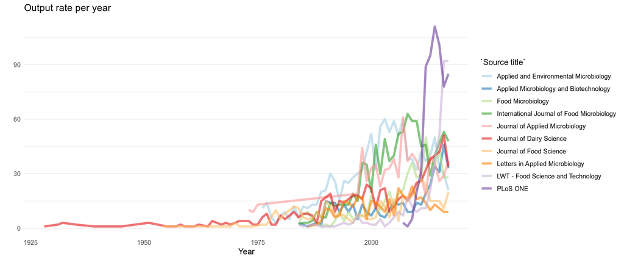

```r
Top10_journals <- scopus %>%
  group_by(`Source title`) %>%
  summarise(count = n()) %>%
  arrange(-count) %>%
  .[1:10,] %>%
  pull(`Source title`)

C1 <- scopus %>%
  filter(Year != 2018) %>%
  filter(`Source title` %in% Top10_journals) %>%
  group_by(`Source title`, Year) %>%
  summarise(count = n()) %>%
  ggplot(aes(x = Year, y = count, group = `Source title`)) +
  geom_line(aes(colour = `Source title`), size = 1.5, alpha = 0.6) +
  theme_minimal() +
  theme(panel.grid.major.x = element_blank(),
        panel.grid.minor.x = element_blank()) +
  ylab("") +
  scale_color_brewer(palette = "Paired") +
  ggtitle("Output rate per year")

C1
```

This did not end up in my thesis, but I was pretty curious at which author published the highest number of Lactobacillus papers.

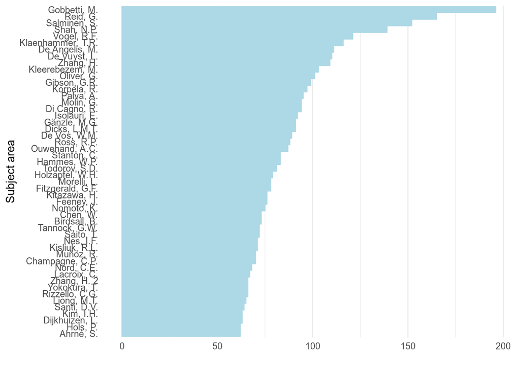

```r
scopus_author_count %>%
  arrange(-count) %>%
  group_by(`AUTHOR NAME`) %>%
  mutate(name = 1:n()) %>%
  ungroup() %>%
  mutate(`AUTHOR NAME` = if_else(name > 1,
                                 str_c(`AUTHOR NAME`, " ", name),
                                 `AUTHOR NAME`)) %>%
  .[1:50,] %>%
  ggplot(aes(x = reorder(`AUTHOR NAME`,count), y = count)) +
  coord_flip() +
  geom_col(colour = "lightblue", fill = "lightblue") +
  theme_minimal() +
  theme(panel.grid.major.y = element_blank(),
        panel.grid.minor.y = element_blank()) +
  ylab("") +
  xlab("Subject area")
```

Now, let’s plot all of these together!

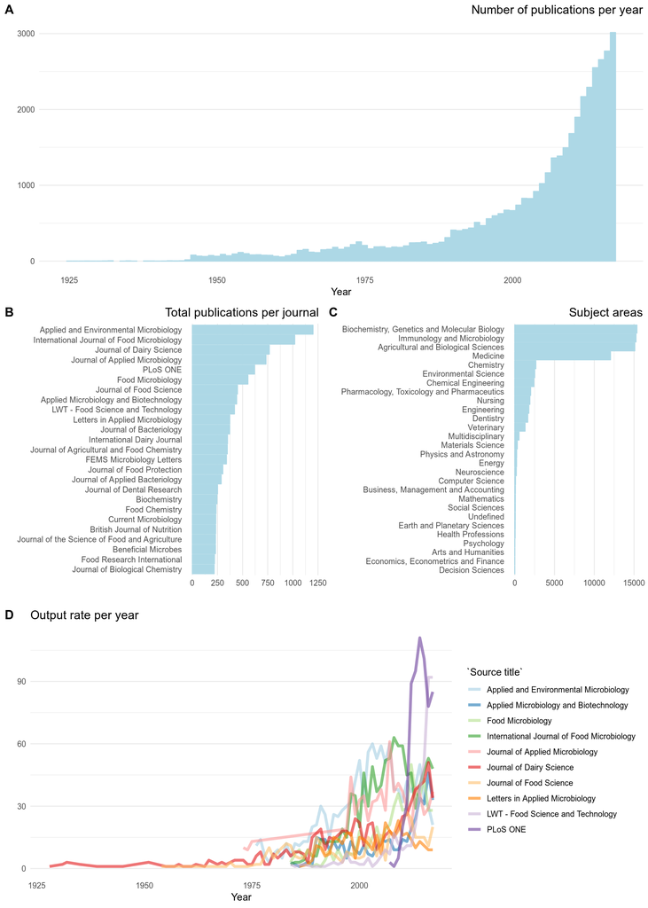

```r
ggarrange(A1,
          ggarrange(B1,D1, labels = c("B", "C")),
          C1,
          labels = c("A","","D"),
          nrow = 3)
```

# Textmining titles

Allright, that was fun. Now let’s do some “text mining” using tidytext!

```r
wordcount <- scopus %>%
  select(Title, Year) %>%
  unnest_tokens(word, Title) %>% # Split title in line per word
  anti_join(stop_words) %>% # Remove "The", "of", "to"
  count(word, sort = T)
```

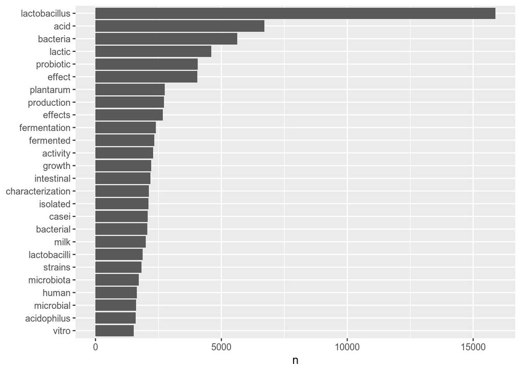

```r
wordcount %>%
  filter(n > 1500) %>%
  mutate(word = reorder(word, n)) %>%
  ggplot(aes(word, n)) +
  geom_col() +
  xlab(NULL) +
  coord_flip()
```

Can we put these in a wordcloud?

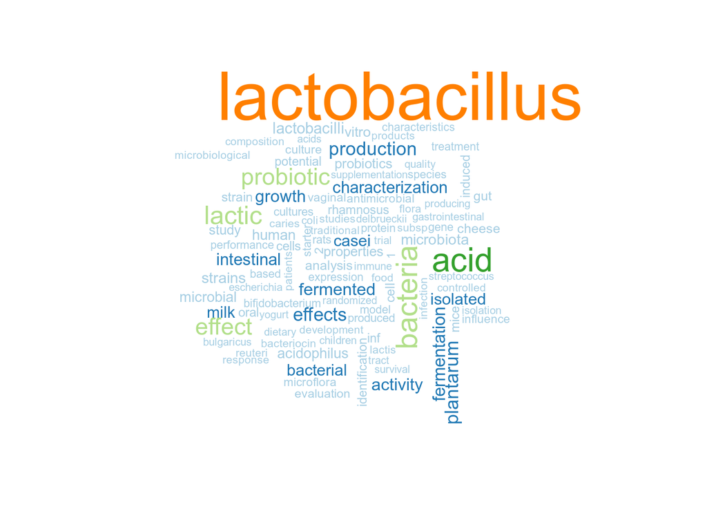

```r
library(wordcloud)
A2 <- wordcount %>%
  with(wordcloud(word, n, max.words = 100, colors = brewer.pal(8, "Paired")))
```

```r
A2
```

Now instead of looking at individual words, let’s look at word pairs

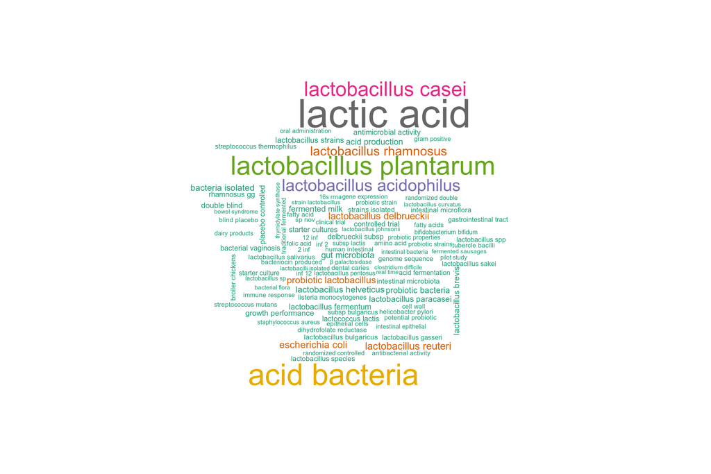

```r
bi_gram <- scopus %>%
  select(Title, Year) %>%
  unnest_tokens(bigram, Title, token = "ngrams", n = 2) %>%
  separate(bigram, c("word1", "word2"), sep = " ") %>%
  filter(!word1 %in% stop_words$word) %>% # Remove word combinations with stopwords
  filter(!word2 %in% stop_words$word) %>%
  unite(bigram, word1, word2, sep = " ") %>% # put word combinations back together
  count(bigram, sort = TRUE)

bi_gram %>%
  with(wordcloud(bigram, n, max.words = 100, colors = brewer.pal(8, "Dark2")))
```

Let’s do the same but with three words instead

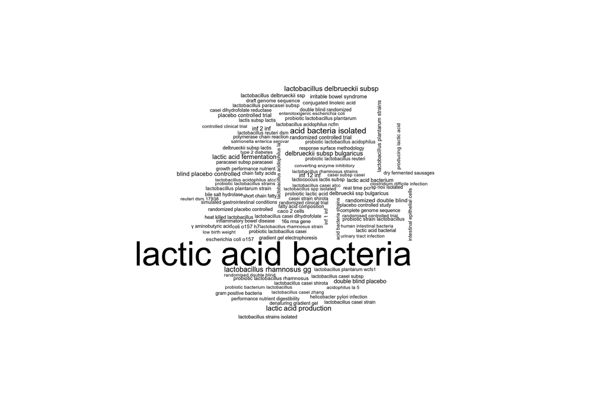

```r
tri_gram <- scopus %>%
  select(Title, Year) %>%
  unnest_tokens(trigram, Title, token = "ngrams", n = 3) %>%
  separate(trigram, c("word1", "word2", "word3"), sep = " ") %>%
  filter(!word1 %in% stop_words$word) %>% # Remove word combinations with stopwords
  filter(!word2 %in% stop_words$word) %>%
  filter(!word3 %in% stop_words$word) %>%
  unite(trigram, word1, word2, word3, sep = " ") %>% # put word combinations back together
  count(trigram, sort = TRUE)

tri_gram %>%
  with(wordcloud(trigram, n, max.words = 100))
```

And what about a graph?

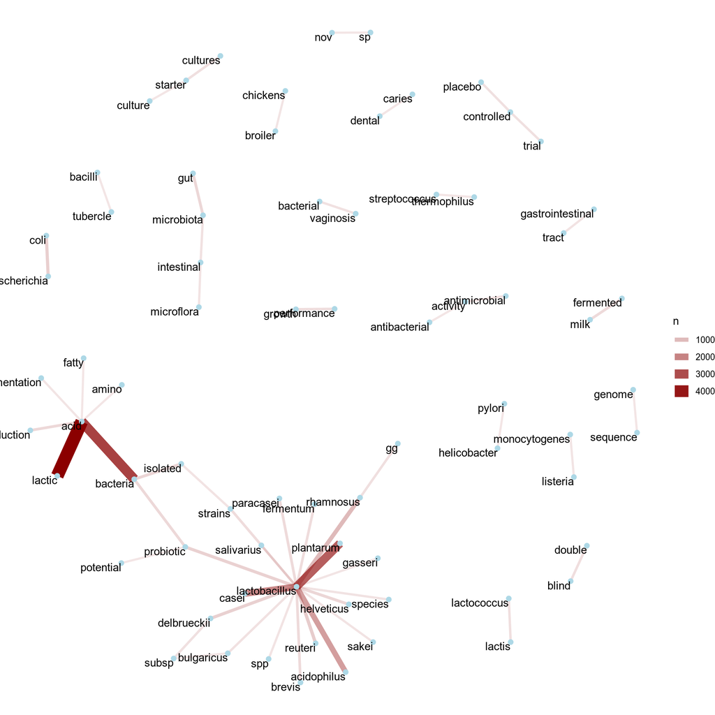

```r
library(igraph)
library(ggraph)
set.seed(2017)


C2 <- bi_gram %>%
  separate(bigram, into = c("word1", "word2")) %>%
  filter(n > 200) %>%
  graph_from_data_frame() %>%
  ggraph(layout = "fr") +
  geom_edge_link(aes(edge_alpha = n, edge_width = n), edge_colour = "darkred") +
  geom_node_point(color = "lightblue", size = 2) +
  geom_node_text(aes(label = name), vjust = 1, hjust = 1) +
  theme_void()
C2
```

# Spielerei

Let’s try to find words related to genome or metagenome.

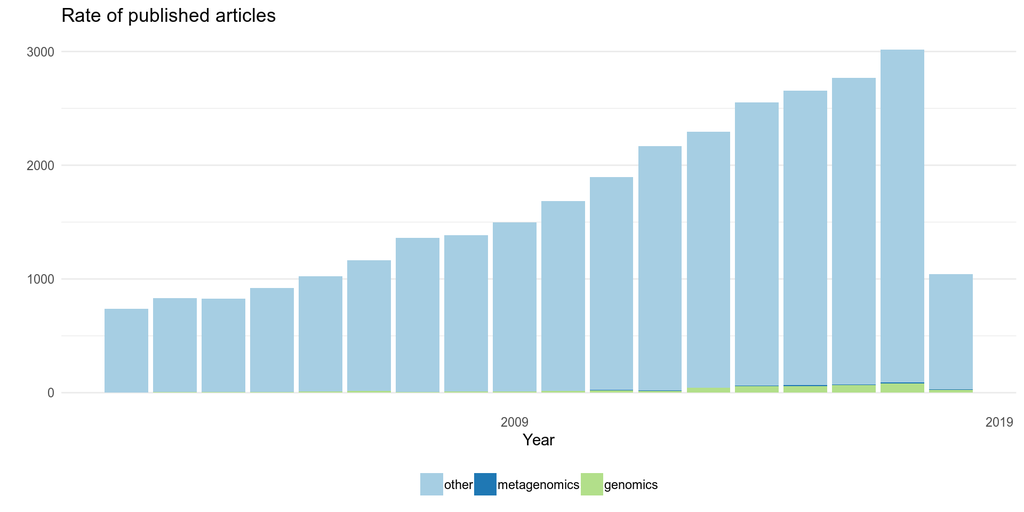

```r
scopus_genome_metagenome <-  scopus %>%
  mutate(subject = as_factor(if_else(str_detect(Title, "metagenom"), 'metagenomics',
                           if_else(str_detect(Title, "genom"), "genomics",
                           "other"))))

scopus_genome_metagenome %>%
  group_by(Year, subject) %>%
  summarise(count = n()) %>%
  ungroup() %>%
  mutate(Year = make_date(Year)) %>%
  filter(Year > make_date("2000")) %>%
  ggplot(aes(x = Year, y = count)) +
  geom_col(aes(fill = subject)) +
  scale_fill_brewer(palette = "Paired") +
  scale_x_date(date_breaks = "10 year", date_labels = "%Y") +
  theme_minimal() +
  theme(panel.grid.major.x = element_blank(),
        panel.grid.minor.x = element_blank(),
        legend.position = "bottom",
        legend.title = element_blank()) +
  ylab("") +
  ggtitle("Rate of published articles")
```

Not sure this analysis is valid. Might work further on it in the future.